# HCH8

4,11,20,26

Question 4 U dataset: MOISSANITE

1. Calculate the regression residuals.
2. Plot the residuals against x. Do you detect a trend?
3. Propose an alternative model based on the plot, part b.
4. Fit and analyze the model you proposed in part c.

```r
setwd("~/Documents/SFSU.FALL.2017/424/R/R/Exercises&Examples")
```

```
The working directory was changed to /home/jondo/Documents/SFSU.FALL.2017/424/R/R/Exercises&Examples inside a notebook chunk. The working directory will be reset when the chunk is finished running. Use the knitr root.dir option in the setup chunk to change the working directory for notebook chunks.
```

1. calculate residuals

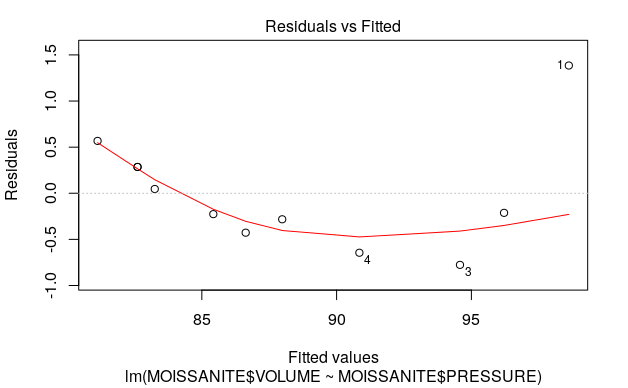

After plotting the residuals of the model, the plot of FItted values vs Residuals, we can see that there is a trend in the residuals and instead of being linear, appears to be quadratic.

The new proposed model is $E(y)=\hat\beta_0 + \hat\beta_1x_1 + \hat\beta_2x_1^2$ Testing this:

```r
model2 = lm(MOISSANITE$VOLUME~MOISSANITE$PRESSURE+I(MOISSANITE$PRESSURE^2))
plot(model2,which = 1:1)
```

[output not shown]

Question 11

E(y) = β 0 + β 1 x 1 + β 2 x 2 + β 3 x 1 x 2 . Fit the model to the data saved in the GASTURBINE file, then plot the residuals against predicted heat rate. Is the assumption of a constant error variance reasonably satisfied? If not, suggest how to modify the model.

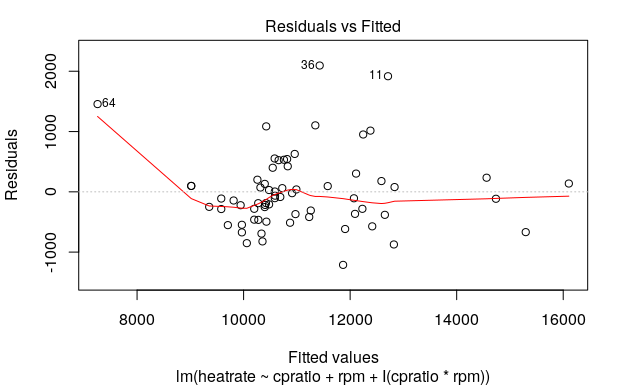

Quesstion 20

The Normal Q-Q plot is displayed below. The chart compares the standardized residuals with the quartiles that should be theoretically exist.

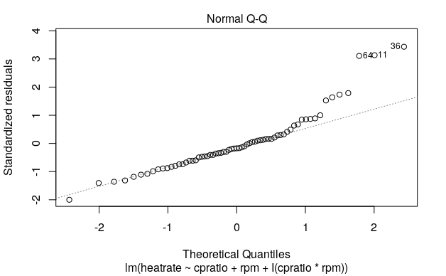